# LA3 One4ALL

Braden Griebel,Luke Fanning, Andrew Duffy, Ahyo Falick

9/10/2019

```r
#Adding data into cdc tibble
library(tidyverse)
source("http://www.openintro.org/stat/data/cdc.R")
cdc <- as_tibble(cdc)
```

# Team Question

**Question**: What effect does having a health plan have on general health, when controlling for smoking and gender?

**Reason**: We would like to discover whether or not health plans have a noticeable effect on people’s health, as this could reveal whether efforts to increase the number of people with a health plan would actually be useful. Additionaly, by controlling for smoking and gender, it is possible to examine in what categories of people health plans make the most difference. Understanding this is important because it could reveal where efforts should be focused to increase the proportion of a specific group with healthplans in order to maximize the increase in health in society as a whole. This would also be useful in maximizing the improvement of average population health per money invested into this program, as obviously the groups that will benefit the most from health care plans will be the most cost effective when considering the overall impact on general health. This research should lead to greater average health of the population.

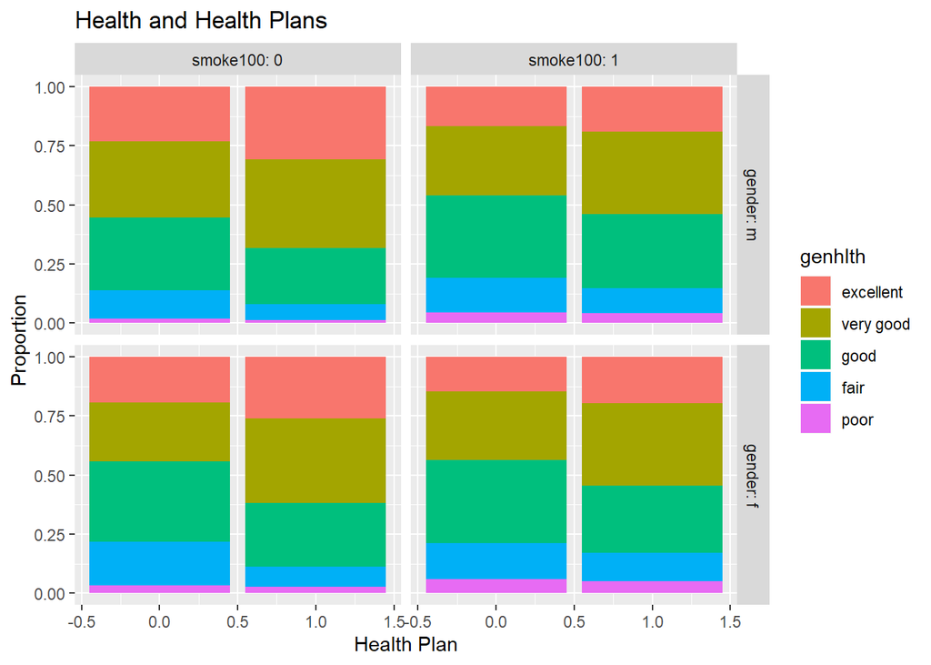

```r
ggplot(data=cdc)+geom_bar(mapping=aes(x=hlthplan, fill=genhlth),position='fill')+facet_grid(gender~smoke100, labeller = label_both)+labs(x='Health Plan',y="Proportion",title="Health and Health Plans")
```

## Conclusion:

First and foremost, it is clear that across all the groups, those with a health plan have a higher proportion of people in the excellent and very good health categories, and smaller amounts in the fair and poor categories. This shows that having a health plan tends to increase the health category that people are in. Since this is true across all the groups that were controlled for, it shows that this is true regardless of gender and smoking habit. However, the actual amount of the increase in those categories varies by different amounts. The change doesn’t vary much between males and females, but it is a significantly smaller increase in those who have smoked 100 cigarettes in their lifetime.It is also relatively obvious that regardless of whether or not a respondent has a health plan or is male or female, there are significantly more respondents in the poor health category among smokers versus non-smokers.

**Recommendation:** Due to the increase in health seen between those without healthplans and those that have healthplans, we recommend efforts be made to increase the amount of the population with health plans. Also, as the actual benefits of a healthplan vary between different groups, we recomend that more data is collected (or that the data in the BRFSS we didn’t have access to be made more widely available) and analyzed to see which groups benefit most from healthplans. Then, those groups can be targeted by either campaigns to increase their desire for healthplans by displaying the potential benefits of having a health plan, or by making healthplans easier to access for those groups, most likely through reducing the cost to those in need who do not have the financial means necessary to pay for a health care plan.

# Braden Griebel Individual Question

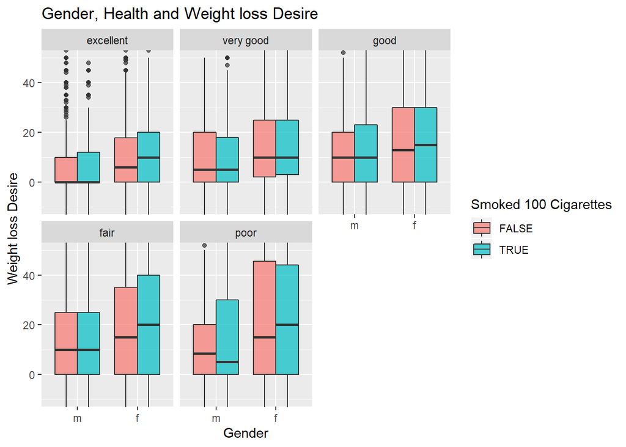

```r
ggplot(data=cdc)+geom_boxplot(mapping=aes(x=gender,y=weight-wtdesire, fill=(smoke100==1)),position="dodge",alpha="0.7")+coord_cartesian(ylim=c(-10,50))+labs(x="Gender",y="Weight loss Desire", fill="Smoked 100 Cigarettes",title="Gender, Health and Weight loss Desire")+facet_wrap(~genhlth,nrow=2)
```

### Findings:

*In this boxplot it can be seen that for all categories, with the single excpetion of poor health males, those who have smoked more than 100 cigarettes want to lose at least as much weight as those who didn’t smoke 100 cigarettes. Also, across all categories females want to loose more weight than the males. Finally, those in better health categories have a smaller difference between their current weight and their deesired weight.*

# Luke Fanning Individual Plot

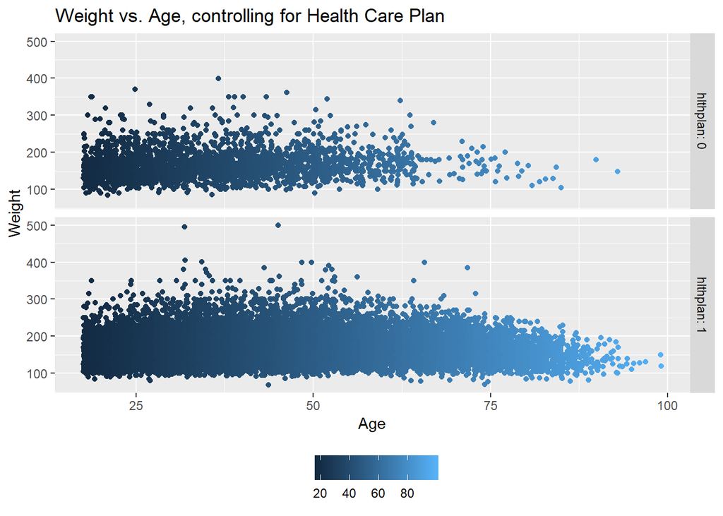

```r
ggplot(data=cdc) + geom_point(mapping = aes(x=age, y= weight, color = age), position = "jitter") + facet_grid(hlthplan ~ ., labeller = "label_both") + theme(legend.position= "bottom") + labs(x="Age", y = "Weight", color = "", title = "Weight vs. Age, controlling for Health Care Plan")
```

# Ahyo Falick Individual Question

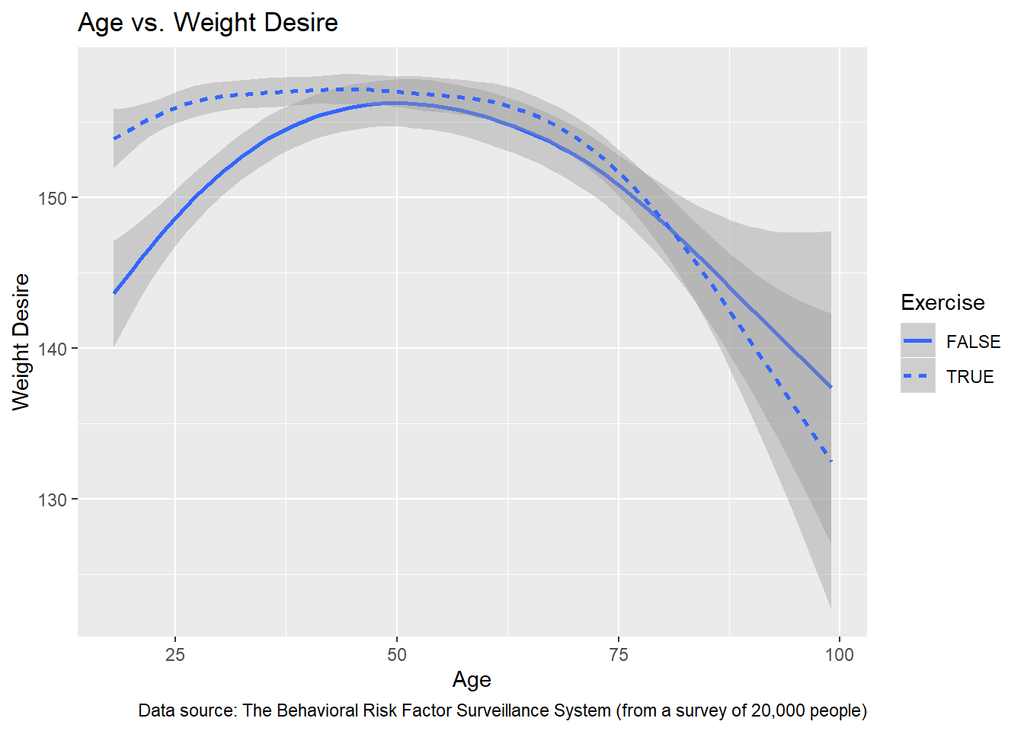

```r
ggplot(data=cdc) + geom_smooth(mapping=aes(x=age,y=wtdesire,linetype=(exerany==1))) + labs(title = "Age vs. Weight Desire", caption = "Data source: The Behavioral Risk Factor Surveillance System (from a survey of 20,000 people)", linetype="Exercise", x="Age", y="Weight Desire")
```

### Findings:

*This graph represents the correlation between age and weight desire. It can be observed that people who exercise more regularly have a higher weight desire on average than those who don’t with the exception of old age. There is a sharp decrease in weight desire among people over the age of 75 and an increase of people up to the age of 50. The data reaches a maximum at age 50, where both exercisers and non-exercisers desire a weight of about 157 pounds. The minimum weight desire occurs when people are 90+ years of age and they want to be, on average, 135 pounds.*

## Summary of Student Contributions:

Ahyo Falick Contribution: I used the geom smooth function to observe the correlation between age and weight desire among the 20,000 people surveyed. The linetype aesthetic was also used while splitting the group between those who exercised in the last month and those who did not. I added a caption detailing from where the data was acquired as well as labels for the axes and linetype to make the data easier to read. The data showed that people generally have an increasing desired weight up until the age of 50 where it decreases until their death. Additionally, people who exercise have a higher average desired weight than those who do not until around their 80’s.

Braden Griebel Contribution: I used the geom_boxplot function to explore the relationship between how much weight people want to loose and gender, general health, and smoking. These data showed that females tend to have a higher amount of desired weight loss, those in better general health categories have lower amounts of weight they want to loose, and smokers tend to want to loose more weight. I used the fill aesthetic to divide the data into those who had smoked and those who hadn’t. I used a facet function to divide the data into different general health categories to make the data easier to understand in the context general health. I also adjusted the labels to make the plot easier to understand.